```python
import sys
!{sys.executable} -m pip install numpy | grep -v 'already satisfied'
!{sys.executable} -m pip install matplotlib | grep -v 'already satisfied'


from IPython.core.display import HTML
table_css = 'table {margin-left: 0 !important;display:block;text-align:left;align-left} '
HTML('<style>{}</style>'.format(table_css))

##### import sys
#!conda install --yes --prefix {sys.prefix} numpy
#!conda install --yes --prefix {sys.prefix} matplotlib


import numpy as np
import matplotlib.pyplot as plt

import ipywidgets as widgets
from IPython.display import display, HTML
```

# Cryptalt's Complete Crypto Guide

A concise overview of crypto assets, investing, and learning resources. by https://twitter.com/cryptaltd

## Disclaimers

None of this guide constitutes financial advice, and is only for information and entertainment purposes. Please consult with the approprriate professional concerning investment decisions, laws, and taxes.

I will NEVER under any circtumstances ask you to send me money or send you money.

Do your own research. Own your portfolio. Own your future. No excuses.

## Interest

### Interest Definitions

| Terrm | Meaning |
| --- | --- |
| Debt | Money owed - |
| Asset | Money owned + |
| Principal | The initial amount before any interest |
| Interest | Percent added to balance of the debt or asset at fixed interval |
| Compound Interest | Interest on the new balance, which is higher due to previous interest. |
| APR | Annual percentage rate of interest excluding compound interest |
| APY | Annual percentage yield of interest including compound interest. APY is higher than APR |
| rate of supply change | the rate at which the supply of a currency changes. This can be linear, decreasing or dynamic |
| inflation | The rate of decrease in the purchasing power of a currency. High increases in the supply of a currency typically cause high inflation |

### APR vs APY

The larger the APR, the larger the difference between APR and APY When comparing rates, be sure you are comparing APR to APR or APY to APY

| APR | APY |
| --- | --- |
| 10% | 10.5% |
| 100% | 171.5% |
| 200% | 635% |
| 500% | 14,246% |

Site for converting APR <-> APY: https://www.aprtoapy.com/

### Compound Interest

> *Compound interest is the most powerful force in the universe. He who understands it, earns it; he who doesn’t, pays it.*

Nothing is more important to your financial future than benefitting from compound interest.

Compound interest is literally the formula for wealth.

Every \$1 invested has the potential to become \\$100 or more. A penny saved is a dollar earned. Spend less. Invest more.

[figure not shown]

Almost all wealth in the world is the result of compound interest over long periods of time. Wealth goes to those who patiently hold appreciating assets for years or decades.

[figure not shown]

The amount of money you start with is important, but the rate of growth is far more important the longer it has time to compound.

> *Time in the market beats timing the market.*

[output not shown]

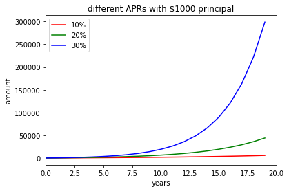

```python
p = 1000
n = 365
t = np.arange(0.0, 20.0, 1.0)

def compound_interest(p, r, n, t):
    return p * (1 + r/n)**(n*t)

def ten_percent(t):
    return compound_interest(p, 10/100, n, t)

def twenty_percent(t):
    return compound_interest(p, 20/100, n, t)

def thirty_percent(t):
    return compound_interest(p, 30/100, n, t)

def ss(t):
    return compound_interest(p, 67/100, n, t)


# Plotting both the curves simultaneously
plt.plot(t, ten_percent(t), color='r', label='10%')
plt.plot(t, twenty_percent(t), color='g', label='20%')
plt.plot(t, thirty_percent(t), color='b', label='30%')

# Naming the x-axis, y-axis and the whole graph
plt.xlabel("years")
plt.ylabel("amount")
plt.title("different APRs with $1000 principal")

plt.xlim([0, 20])
# Adding legend, which helps us recognize the curve according to it's color
plt.legend()

# To load the display window
plt.show()

state = False
toggle_code(state)
```

### Rule of 72:

*The number of years it takes for your money to double is 72 divided by your interest rate.*

| APR | Years to double |
| --- | --- |
| 4% | 18 years |
| 8% | 9 years |
| 16% | 4.5 years |
| 32% | 2.3 years |
| 64% | 1.1 years |
| 128% | 0.6 years |

### Formulas:

#### Compound Interest

a = p * (1 + r/n)^(nt)

Where a = amount, = principal, r = apr, n = number of compoundings per unit time, t = count of unit time (usually year)

#### APY to APR

const apyToApr = (interest, frequency) => ((1 + (interest / 100)) * *(1 / frequency) - 1)* frequency * 100;

#### APR to APY

const aprToApy = (interest, frequency) => ((1 + (interest / 100) / frequency) * *frequency - 1)* 100;

## Assets: Grow your capital

### Types of Assets

[output not shown]

| Crypto Asset | APR (est) | Volatility (est) |
| --- | --- | --- |
| Coin/token | 200% | -95% to 300% |
| Liquidity Farm | 5%-200% | -99% to 600% |
| Stablecoin Yield | 1%-18% | -1% to 1% |

## Buying and Selling

> *You've got to know when to hold 'em Know when to fold 'em Know when to walk away And know when to run*

```
– Kenny Rogers, (The Gambler)
```

### The problem of timing the market

Missing even a few of the best performing days can destroy all of your gains.

#### \$10k Investment S&P 500 from 2000-2020

| Best days missed | Dollar Value | Annualized Performance |
| --- | --- | --- |
| Fully invested | \$32,421 | 6.06% |
| Missed 10 best days | \$16,180 | 2.44% |
| Missed 20 best days | \$10,176 | 0.08% |
| Missed 30 best days | \$6,749 | (1.95%) |
| Missed 40 best days | \$4,607 | (3.8%) |
| Missed 50 best days | \$3,246 | (5.47%) |
| Missed 60 best days | \$2,331 | (7.02%) |

Source: [The Motley Fool](https://www.fool.com/investing/2020/12/31/missing-just-a-few-of-the-best-stock-market-days-c/)

### Strategies for buying and selling

#### Buy and Hold (Hodl)

With buy and hold, you buy but never sell Bitcoin. Over long periods of time, this has proven an extremely effective strategy since Bitcoin has averaged around 200% returns this past decade.

#### Dollar Cost Averaging (DCA)

With dollar cost averaging, you purchase at a regular interval, e.g. weekly, monthly. If you start with limited capital, this can be a very effective strategy for building wealth.

#### Lump Sum Investing

> The best time to buy Bitcoin was 5 years ago. The second best time is now.

With lump sum investing, you invest a large sum and never sell, with the goal of maximizing time in the market.

[figure not shown]

Source: https://www.coinbase.com/learn/tips-and-tutorials/dollar-cost-averaging

#### Active Tradig

In active trading you try to predict when the market will go up or down. Most traders fail horribly at this, especially when taxes are taken into account. It's easy to say you will buy the dip and sell the pump, but the default of human psychology is to do the exact opposite.

> "We think we are wolves, living by the logic of the pack.  
> In truth we are sheep, living by the logic of the flock.  
> Sheep are evolved to have a specific type of intelligence which has the following hallmarks.
> 1. Enormous capacity for other-regarding behaviors.

> Sheep are unbelievably sensitive to what other sheep are doing and their emotional states....
> 2. Zero altruism and overwhelming selfishness....
> 3. The determination to pursue any behavior that meets Hallmark 1 and 2 to absurd ends, even unto death....

> My worst sheep suicide story? The first year we kept sheep, we thought it would make sense to set up a hay net in their pen, which keeps the hay off the ground and lets the sheep feed themselves by pulling hay through the very loose loops of the net. Turned out, though, that the loops were so loose that a determined sheep could put her entire head inside the net, and if one sheep could do that, then two sheep could do that.  
> And given how the hay net was hung and how these sheep were sensing each other, they started to move clockwise in unison, each trying to get an advantage over the other, still with their heads stuck in the net. At which point the net starts to tighten. And tighten. And tighten. My daughter found them the next morning, having strangled each other to death, unable to stop gorging themselves or seeking an advantage from the behavior of others. The other sheep were crowded around, stepping around the dead bodies, pulling hay for themselves out of the net. That was a bad day.  
> In both markets and in politics, our human intelligences are being trained to be sheep intelligences."  
> — https://www.epsilontheory.com/sheep-logic/

To be successful as a trader, you must know yourself, know your own emotions and have an edge in predicting where the market is going. Be very careful using active trading and ensure you are using risk management to preserve your capital.

Active trading techniques attempt to identify market sentiment and momentum to determine areas of high reward to risk.

Popular techniques for active trading include:

- technical analysis of chart patterns to determine market sentiment and momentum
- order flow analysis of buy and sell orders on exchanges
- on-chain metrics for when coins are moved from exchanges to wallets or wallets to exchanges
- market cycle indicators

#### Market cycle indicators

##### Logarithmic Regression - BTC/ETH rainbow chart

In this strategy, you buy when the price of Bitcoin or Ethereum is significantly below it's logarithmic regression trend (blue/green) and you sell when it's significantly above (orange/red)

[figure not shown]

Source: https://www.blockchaincenter.net/bitcoin-rainbow-chart/

See also: https://www.blockchaincenter.net/ethereum-rainbow-chart/

##### Pi Cycle Top Indicator

In this strategy, you wait for the value of the 350 daily moving average x2 (orange line) to pass the 111 daily moving averagee (green line) as a sell signal.

[figure not shown]

https://www.lookintobitcoin.com/charts/pi-cycle-top-indicator/

### Portfolio Allocation

[figure not shown]

### Decentralized Finance

#### Liquidity - the most valuable part of any market

#### Order Book

#### AMM

#### Liquidity Pool

#### Auto-compounding

#### Impermanent Loss